# Math 253 Assignment 4

Jingjing Yang

10-15-2015

# Computing Assignments

## 4.7.11 Predict whether a car gets high or low gas mileage

### (a) Create binary variable mpg01

```r
library(ISLR)
car_median <- median(Auto$mpg)
Auto$mpg01 <- ifelse(Auto$mpg>car_median,1,0)
```

### (b) What other features seem useful in predicting mpg01

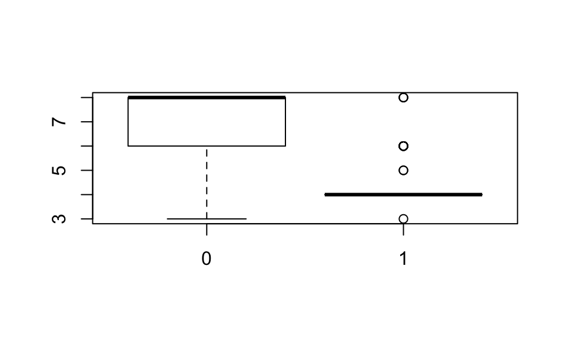

```r
with(Auto, boxplot(cylinders~mpg01))
```

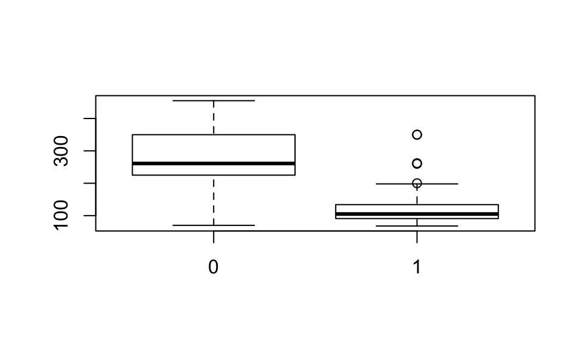

```r
with(Auto, boxplot(displacement~mpg01))
```

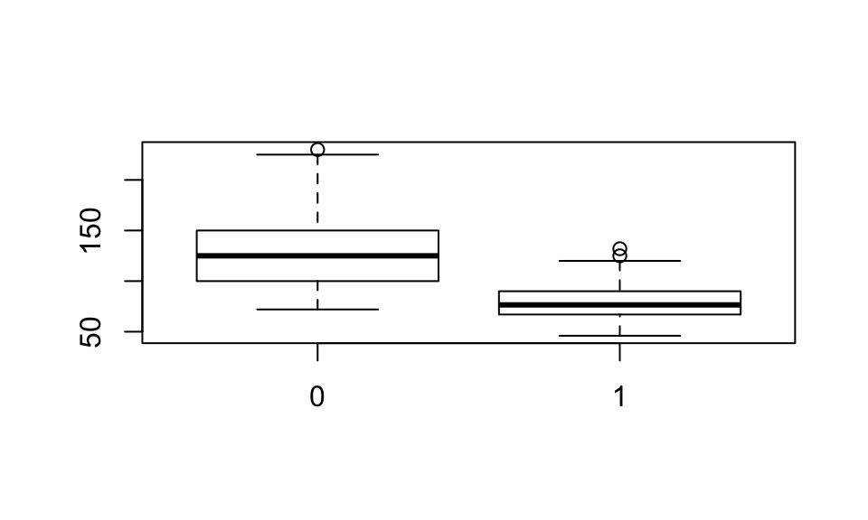

```r
with(Auto, boxplot(horsepower~mpg01))
```

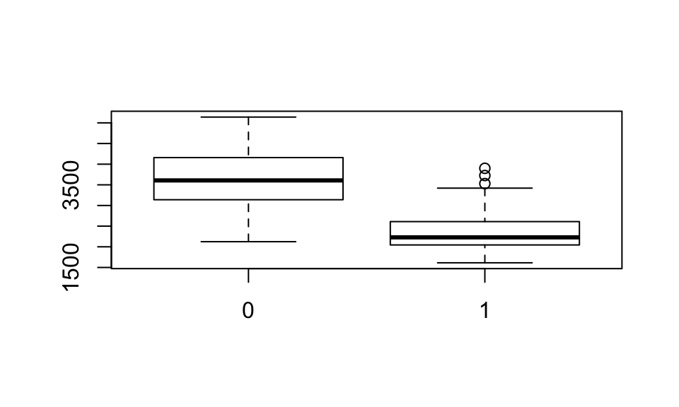

```r
with(Auto, boxplot(weight~mpg01))
```

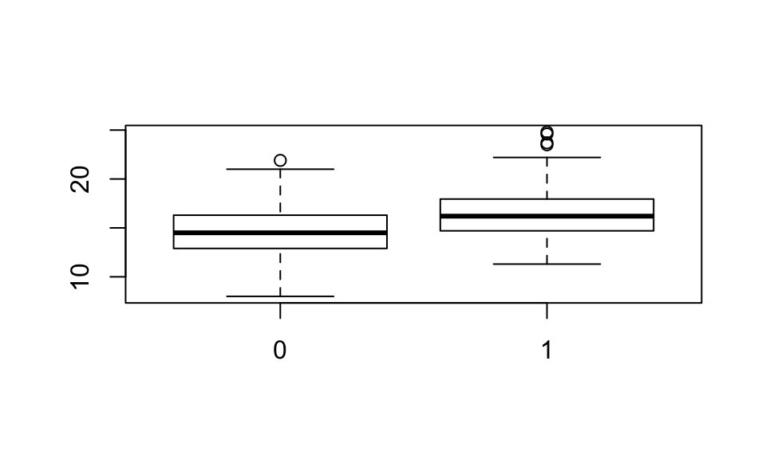

```r
with(Auto, boxplot(acceleration~mpg01))
```

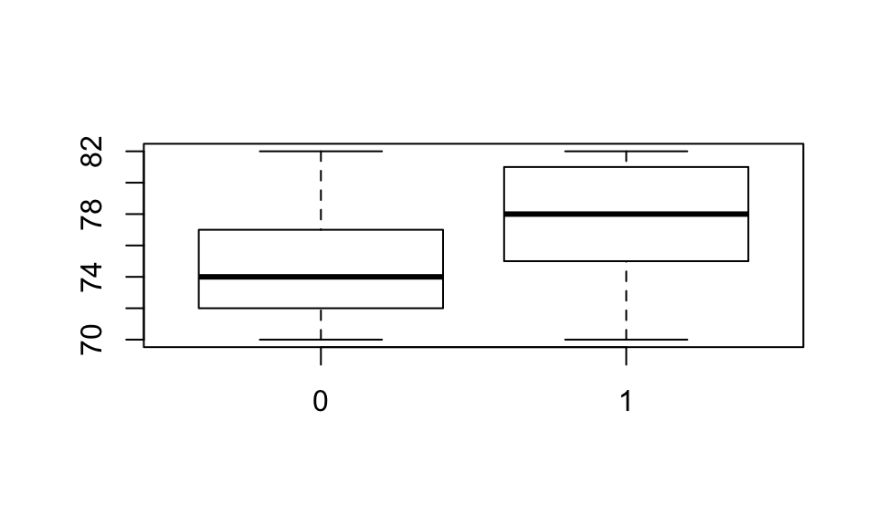

```r
with(Auto, boxplot(year~mpg01))
```

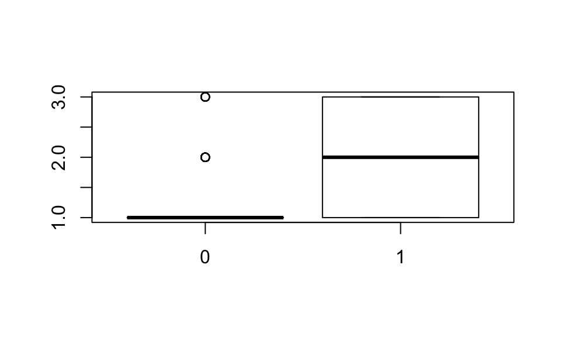

```r
with(Auto, boxplot(origin~mpg01))
```

With the above boxplots, I find that cylinders, displacement, horsepower, weight and origin seem to have relatively stronger relationship with mpg01, thus more likely to be useful in predicting mpg01.

### (c) Split the data into training and test sets.

```r
nrow(Auto)
```

```
## [1] 392
```

```r
training <- Auto[c(1:150),]
test <- Auto[-c(1:150),]
```

### (d) Perform LDA on the training and test data

```r
library(MASS)
lda_fit <- lda(mpg01~cylinders + displacement + horsepower + weight + origin, data = training)
lda_pred <- predict(lda_fit, test)
table(lda_pred$class, test$mpg01)
```

```
##
##       0   1
##   0  83  42
##   1  10 107
```

```r
1 - mean(lda_pred$class == test$mpg01)
```

```
## [1] 0.214876
```

### (e) Perform QDA on the training and test data

```r
qda_fit <- qda(mpg01~cylinders + displacement + horsepower + weight + origin, data = training)
qda_pred <- predict(qda_fit, test)
table(qda_pred$class, test$mpg01)
```

```
##
##       0   1
##   0  89  24
##   1   4 125
```

```r
1 - mean(qda_pred$class == test$mpg01)
```

```
## [1] 0.1157025
```

The test error with a quadratic discriminant analysis is 0.12.

### (f) Perform logistic regression on the training and test data

```r
#training data
glm_fit <- glm(mpg01~cylinders + displacement + horsepower + weight + origin, data = training, family = binomial)
glm_probs <- predict(glm_fit, data = training, type = "response")
glm_pred <- rep("0", 150)
glm_pred[glm_probs>0.5] = "1"
table(glm_pred, training$mpg01)
```

```
##
## glm_pred  0  1
##        0 94  5
##        1  9 42
```

```r
mean(glm_pred == training$mpg01)
```

```
## [1] 0.9066667
```

```r
#test data
glm_probs_test <- predict(glm_fit, data=test, type = "response")
glm_pred <- rep("0", 242)
glm_pred[glm_probs>0.5] = "1"
table(glm_pred, test$mpg01)
```

```
##
## glm_pred   0   1
##        0  63 100
##        1  30  49
```

```r
1 - mean(glm_pred == test$mpg01)
```

```
## [1] 0.5371901
```

The test error with a logistic regression is 0.54.

### (g) Perform KNN on the training and test data

```r
library(class)
train_X <- cbind(training$cylinders, training$displacement, training$horsepower, training$weight, training$origin)
test_X <- cbind(test$cylinders, test$displacement, test$horsepower, test$weight, test$origin)
train_direction <- factor(training$mpg01)

set.seed(1)
knn_pred <- knn(train_X, test_X, train_direction, k = 1)
table(knn_pred, test$mpg01)
```

```
##
## knn_pred   0   1
##        0  91  41
##        1   2 108
```

```r
1 - mean(knn_pred == test$mpg01)
```

```
## [1] 0.177686
```

```r
knn_pred2 <- knn(train_X, test_X, train_direction, k = 2)
table(knn_pred2, test$mpg01)
```

```
##
## knn_pred2   0   1
##         0  89  39
##         1   4 110
```

```r
1 - mean(knn_pred2 == test$mpg01)
```

```
## [1] 0.177686
```

```r
knn_pred3 <- knn(train_X, test_X, train_direction, k = 3)
table(knn_pred3, test$mpg01)
```

```
##
## knn_pred3   0   1
##         0  90  42
##         1   3 107
```

```r
1 - mean(knn_pred3 == test$mpg01)
```

```
## [1] 0.1859504
```

```r
knn_pred6 <- knn(train_X, test_X, train_direction, k = 6)
table(knn_pred6, test$mpg01)
```

```
##
## knn_pred6  0  1
##         0 91 55
##         1  2 94
```

```r
1 - mean(knn_pred6 == test$mpg01)
```

```
## [1] 0.2355372
```

```r
knn_pred10 <- knn(train_X, test_X, train_direction, k = 10)
table(knn_pred10, test$mpg01)
```

```
##
## knn_pred10  0  1
##          0 92 55
##          1  1 94
```

```r
1 - mean(knn_pred10 == test$mpg01)
```

```
## [1] 0.231405
```

## 4.7.13 Predict whether a suburb has a crime rate above or below median

```r
median <- median(Boston$crim)
# If a suburb has a crime rate higher than the median, it gets a "0" for its safety variable, and 1 otherwise.
Boston$safety <- ifelse(Boston$crim > median,0,1)
training <- Boston[c(1:200),]
test <- Boston[-c(1:200),]
```

### Determine which predictors might be useful

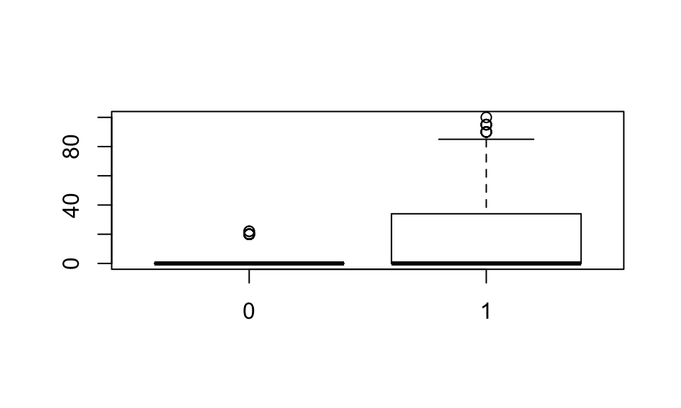

```r
boxplot(Boston$zn~Boston$safety)
```

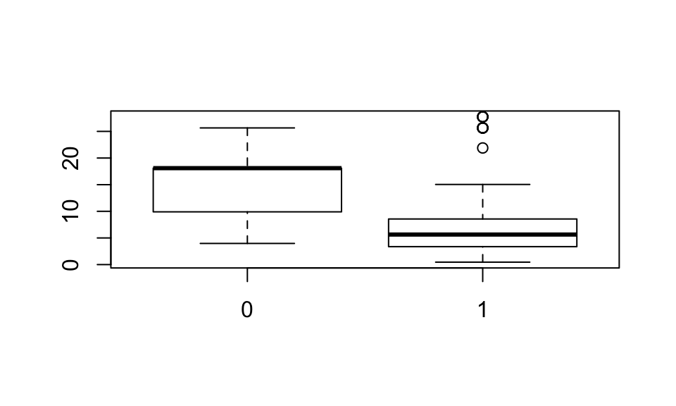

```r
boxplot(Boston$indus~Boston$safety)
```

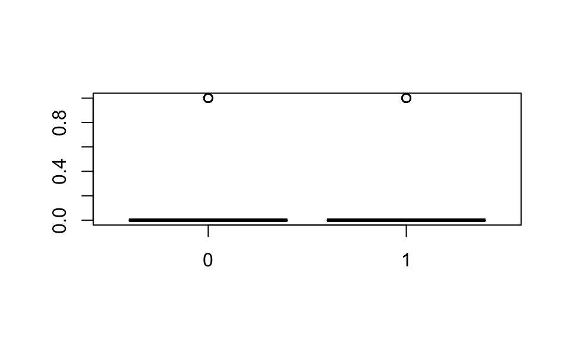

```r
boxplot(Boston$chas~Boston$safety)
```

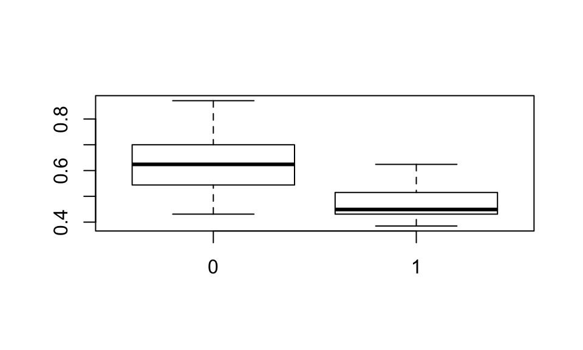

```r
boxplot(Boston$nox~Boston$safety)
```

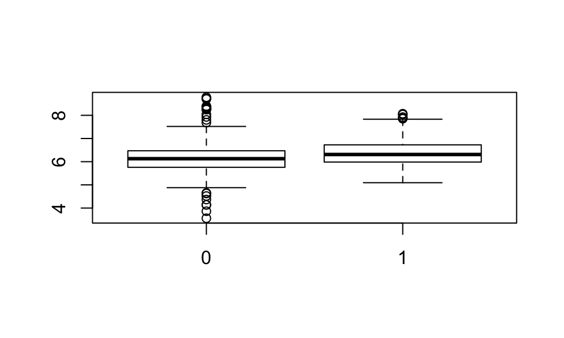

```r
boxplot(Boston$rm~Boston$safety)
```

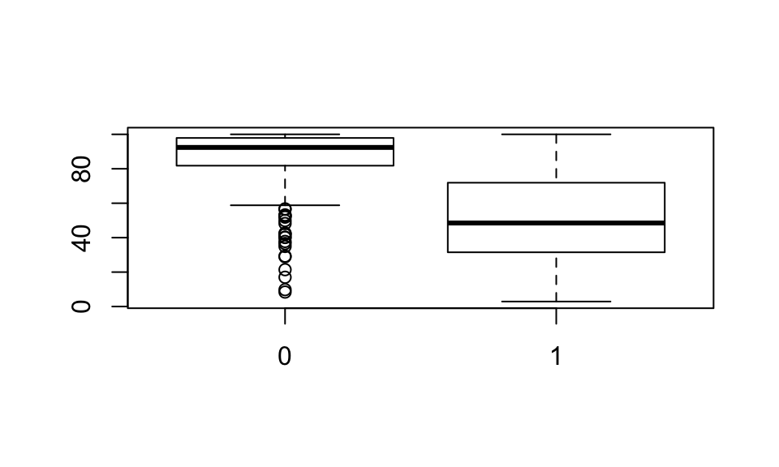

```r
boxplot(Boston$age~Boston$safety)
```

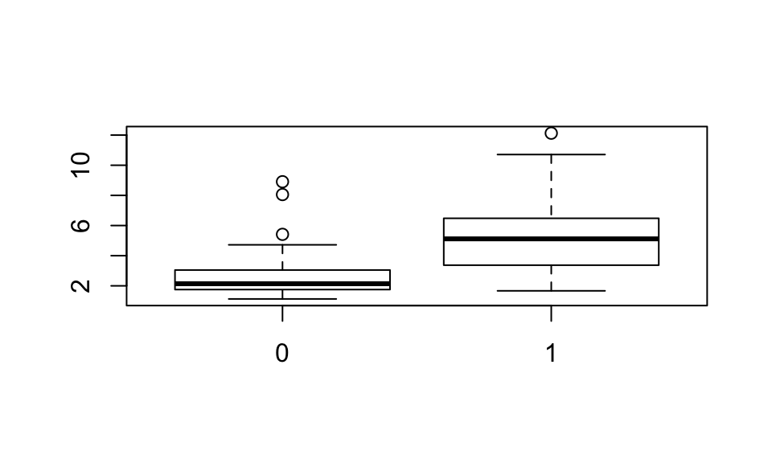

```r
boxplot(Boston$dis~Boston$safety)
```

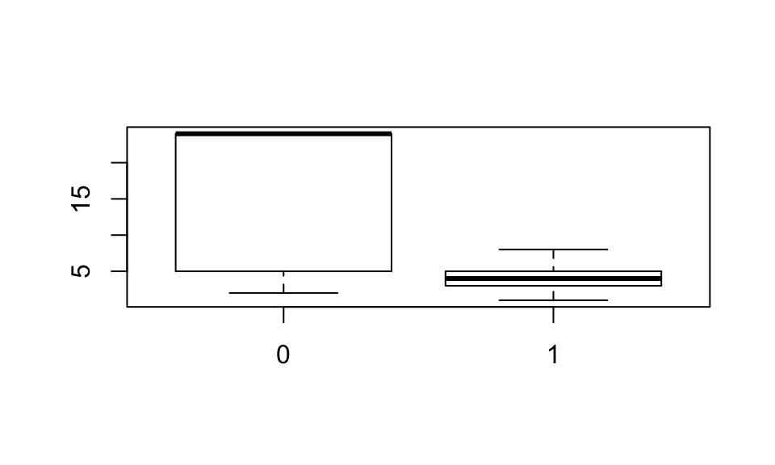

```r
boxplot(Boston$rad~Boston$safety)
```

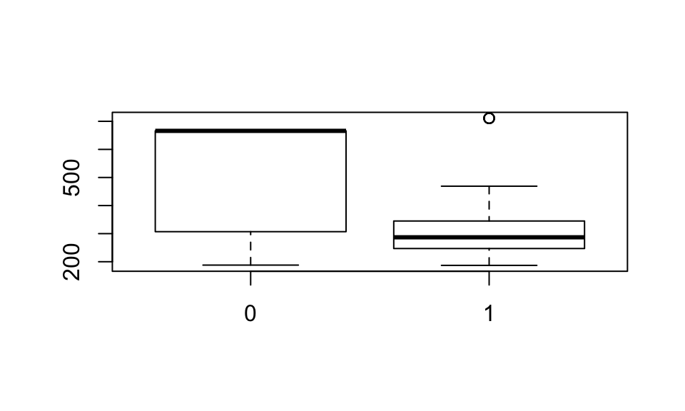

```r
boxplot(Boston$tax~Boston$safety)
```

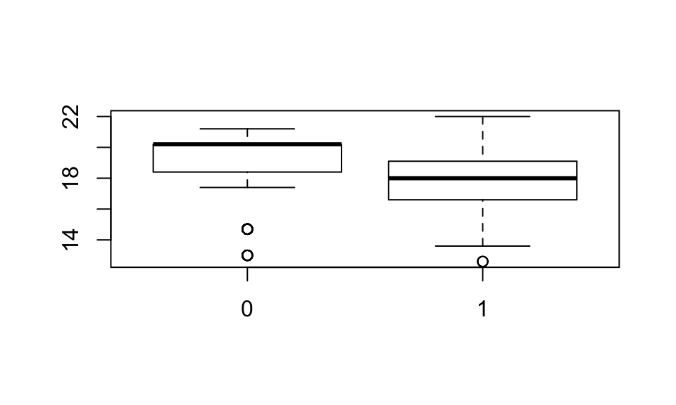

```r
boxplot(Boston$ptratio~Boston$safety)
```

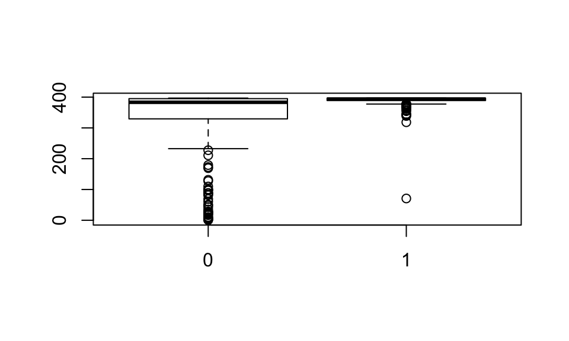

```r
boxplot(Boston$black~Boston$safety)
```

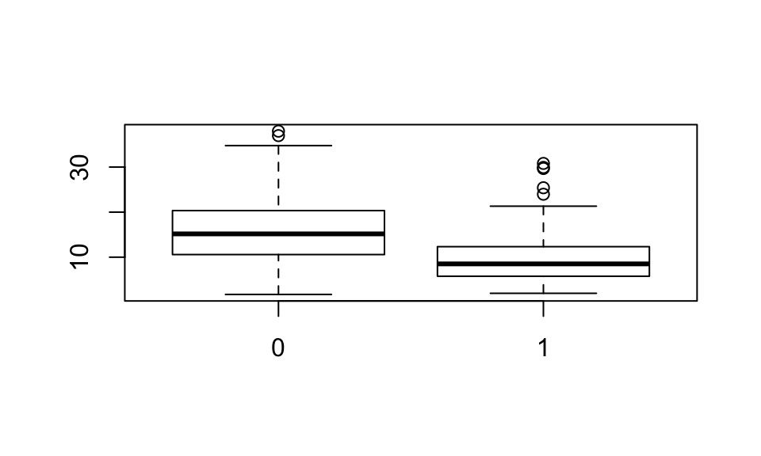

```r
boxplot(Boston$lstat~Boston$safety)
```

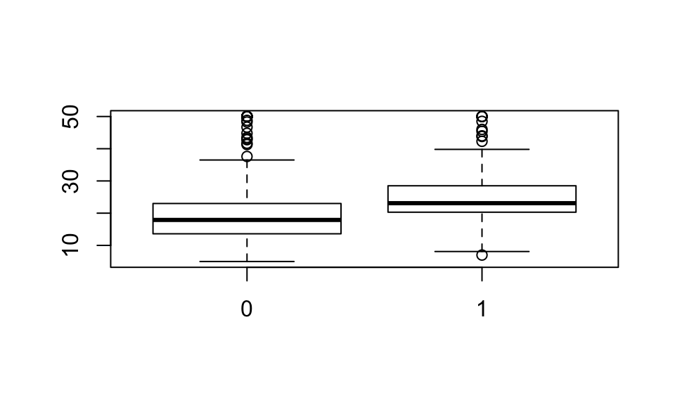

```r
boxplot(Boston$medv~Boston$safety)
```

With the above boxplots, I find that zn, indus, nox,age,dis, rad, and tax seem to have relatively stronger relationship with safety, thus more likely to be useful in predicting safety.

### Logistic Regression

```r
glm_fit <- glm(safety~zn + indus + nox + age + dis + rad + tax, data = training, family = binomial)
summary(glm_fit)
```

```
##
## Call:
## glm(formula = safety ~ zn + indus + nox + age + dis + rad + tax,
##     family = binomial, data = training)
##
## Deviance Residuals:
##     Min       1Q   Median       3Q      Max
## -3.3437  -0.0906   0.0000   0.0525   2.5659
##
## Coefficients:
##               Estimate Std. Error z value Pr(>|z|)
## (Intercept)  107.95272   25.60693   4.216 2.49e-05 ***
## zn             2.16538  235.52643   0.009  0.99266
## indus          0.58190    0.24599   2.366  0.01800 *
## nox         -196.19571   51.01582  -3.846  0.00012 ***
## age           -0.05316    0.03709  -1.433  0.15177
## dis           -2.98343    1.04638  -2.851  0.00436 **
## rad           -0.34450    1.27358  -0.270  0.78678
## tax            0.02302    0.01983   1.161  0.24582
## ---
## Signif. codes:  0 '***' 0.001 '**' 0.01 '*' 0.05 '.' 0.1 ' ' 1
##
## (Dispersion parameter for binomial family taken to be 1)
##
##     Null deviance: 256.41  on 199  degrees of freedom
## Residual deviance:  32.23  on 192  degrees of freedom
## AIC: 48.23
##
## Number of Fisher Scoring iterations: 22
```

Since the P-value for zn, rad and tax are relatively large, we will eliminate those variables from the model. The following is the logistic regression applied to the new model.

```r
glm_fit <- glm(safety~indus + nox + age + dis, data = training, family = binomial)
glm_probs <- predict(glm_fit, data = test, type = "response")
glm_pred <- rep("1", 306)
glm_pred[glm_probs < 0.5] = "0"
table(glm_pred, test$safety)
```

```
##
## glm_pred   0   1
##        0  59  36
##        1 126  85
```

```r
#correct rate
mean(glm_pred == test$safety)
```

```
## [1] 0.4705882
```

### LDA

```r
lda_fit <- lda(safety~indus + nox + age+dis, data = training)
lda_pred <- predict(lda_fit, test)
table(lda_pred$class, test$safety)
```

```
##
##       0   1
##   0 124   6
##   1  61 115
```

```r
#correct rate
mean(lda_pred$class == test$safety)
```

```
## [1] 0.7810458
```

### KNN

```r
train_X <- cbind(training$indus, training$nox, training$age, training$dis)
test_X <- cbind(test$indus, test$nox, test$age, test$dis)
train_direction <- factor(training$safety)

set.seed(1)

# K = 1
knn_pred <- knn(train_X,test_X,train_direction, k = 1)
table(knn_pred, test$safety)
```

```
##
## knn_pred   0   1
##        0 127   5
##        1  58 116
```

```r
mean(knn_pred == test$safety)
```

```
## [1] 0.7941176
```

```r
# K = 2
knn_pred2 <- knn(train_X,test_X,train_direction, k = 2)
table(knn_pred2, test$safety)
```

```
##
## knn_pred2   0   1
##         0 126   4
##         1  59 117
```

```r
mean(knn_pred2 == test$safety)
```

```
## [1] 0.7941176
```

```r
# K = 4
knn_pred4 <- knn(train_X,test_X,train_direction, k = 4)
table(knn_pred4, test$safety)
```

```
##
## knn_pred4   0   1
##         0 123   3
##         1  62 118
```

```r
mean(knn_pred4 == test$safety)
```

```
## [1] 0.7875817
```

```r
# K = 6
knn_pred6 <- knn(train_X,test_X,train_direction, k = 6)
table(knn_pred6, test$safety)
```

```
##
## knn_pred6   0   1
##         0 122   3
##         1  63 118
```

```r
mean(knn_pred6 == test$safety)
```

```
## [1] 0.7843137
```

In conclusion, the KNN algorithm has the highest correct prediction rate of about 79%, with monior fluaction given different K values.

# Theory Assignments

## 4.7.1

### To show equation (4.2) and (4.3) are equivalent:

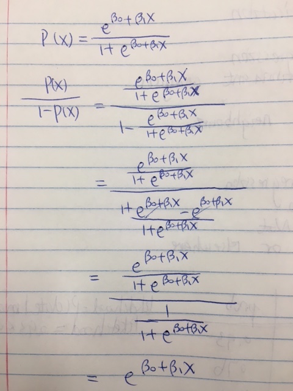

## 4.7.8

We shou choose the logistic regression model because when K = 1, the training error of KNN is just zero, which means the test error rate is 36%, higher than that of the logistic regression.

## 4.7.9

### (a) 27% of the people with an odds of 0.37 of defaulting actually default.

### (b) The odds that she will default is 0.19.